# classifier

Here I will analyze mBAL data to test how well we can predict LRTI using FABP4 and Versa.

# Load packages

```r
library(tidyverse)
library(ggplot2)
library(ggalluvial)
library(patchwork)

library(DESeq2)
library(pROC)
```

Specify ggplot2 theme

```r
# General theme
my.theme <- theme(
  plot.title = element_text(hjust = 0.5, size=12, face="plain"),
  axis.text = element_text(size=12, color="black"),
  text = element_text(size=12, family="Arial"),
  panel.grid.major = element_blank(),
  panel.grid.minor = element_blank(),
  plot.margin = unit(c(0.3,1,0.7,0), "cm")
  )

# Confusion matrix theme
my.theme.cm <- theme(
  plot.title = element_text(hjust = 0.5, size=12, face="plain"),
  text = element_text(size=12, family="Arial"),
  axis.text = element_text(size=10, color="black"),
  panel.grid.major = element_blank(),
  panel.grid.minor = element_blank(),
  plot.margin = unit(c(0.3,1,0.7,0), "cm")
  )
```

Color choices (take from seaborn colorlind palette)

```r
# GPT-4 only:
color.gpt4 <- "#0173b2"
# FABP4 only:
color.fabp4 <- "#de8f05"
# FABP4 + GPT-4:
color.integrated <- "#029e73"
# Initial diagnosis:
color.initial <- "#cc78bc"
# Naive physicians:
color.naive <- "#ece133"
```

# Import mBAL data

The count table was downloaded from https://github.com/infectiousdisease-langelier-lab/LRTI_FABP4_classifier/blob/main/adult_count/merged_counts.csv

```r
# Counts
counts.adult <- read.csv(
  "merged_counts.csv",
  row.names=1, check.names=FALSE)
# Save gene symbol and gene ID
gene.symbol <- counts.adult[,"gene_symbol",drop=FALSE]

# Metadata that contains Versa score
metadata.adult <- read.csv(
  "metadata/metadata_simplified.csv",
  row.names=NULL
)
colnames(metadata.adult) <- gsub(" ",".", colnames(metadata.adult), fixed=TRUE)
metadata.adult$patient_id <- as.character(metadata.adult$patient_id)
metadata.adult$LRTI <- factor(metadata.adult$LRTI, levels=c(0,1))

# Remove excluded and prompt engineering patients
metadata.adult <- metadata.adult %>%
  subset((is.na(Exclude.Patient)) | (Exclude.Patient!="Y")) %>%
  subset(!(patient_id %in% c("205","208","211","213","439")))

# Versa score is stored in 2 columns: 1 as character, 1 as numeric
metadata.adult$Versa.LRTI.score.factor <- as.character(metadata.adult$Versa.LRTI.score)
metadata.adult$Versa.LRTI.score <- as.numeric(metadata.adult$Versa.LRTI.score)

# Verify that there is no Na Versa score
stopifnot(!is.na(metadata.adult$Versa.LRTI.score))
stopifnot(!is.na(metadata.adult$Versa.LRTI.score.factor))

# Number of samples per LRTI status
print(table(metadata.adult$LRTI))
```

```
 0  1
49 39
```

Calculate Versa’s accuracy vs true diagnosis

```r
metadata.adult$accuracy <- ifelse(
  metadata.adult$LRTI=="0",
  (3-metadata.adult$Versa.LRTI.score)/3,
  metadata.adult$Versa.LRTI.score/3)
```

## Import initial ICU diagnosis

The column `Clinical_LRTI` contains the real-time clinician adjudication, based on the clinician’s abx prescription.

```r
initial.icu <- read.csv(
  "metadata/initial_icu.csv",
  row.names=NULL
)

initial.icu$patient_id <- as.character(initial.icu$patient_id)

head(initial.icu)
```

|  | patient_id | LRTI | Clinical_LRTI |
| --- | --- | --- | --- |
| 1 | 212 | 1 | 1 |
| 2 | 215 | 0 | 1 |
| 3 | 218 | 0 | 0 |
| 4 | 220 | 0 | 1 |
| 5 | 221 | 0 | 1 |
| 6 | 225 | 1 | 1 |

Merge abx info with data file

```r
metadata.adult <- merge(
  metadata.adult, initial.icu[,c("patient_id","Clinical_LRTI")],
  by="patient_id",
  all.x=TRUE, all.y=FALSE,
  sort=FALSE
)
stopifnot(!is.na(metadata.adult$Clinical_LRTI))
metadata.adult$Clinical_LRTI <- factor(metadata.adult$Clinical_LRTI, levels=c(0,1))
```

## Import GPT-4 comparison physician diagnosis

Here we call GPT-4 comparison physicians “naive physicians” in short.

```r
naive <- read.csv(
  "metadata/gpt4_comparison_physician_score.csv",
  row.names=NULL
)
naive$LRTI <- as.character(naive$LRTI)
```

# Initial ICU vs true diagnosis

```r
# Number of patients per predicted and true LRTI diagnosis
temp <- metadata.adult %>%
  select(patient_id, LRTI, Clinical_LRTI) %>%
  group_by(LRTI, Clinical_LRTI) %>%
  summarise(count = n(), .groups = 'drop')
print(temp)
```

| LRTI | Clinical_LRTI | count |
| --- | --- | --- |
| 0 | 0 | 26 |
| 0 | 1 | 23 |
| 1 | 0 | 1 |
| 1 | 1 | 38 |

Plot confusion matrix.

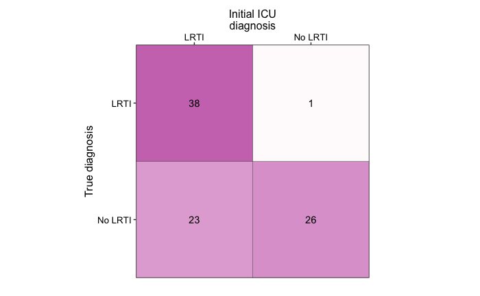

```r
p.initial <- ggplot(
  data=temp,
  aes(x=Clinical_LRTI, y=LRTI)) +
  geom_tile(aes(fill=count), color="black") +
  geom_text(aes(label=count), vjust = 0.5) +
  labs(x="Initial ICU\ndiagnosis",
       y="True diagnosis") +
  scale_fill_gradient(
    low="white", high=color.initial,
    limits=c(0,38), guide="none") +
  scale_x_discrete(
    expand=c(0,0), limits=c("1","0"),
    labels=c("LRTI","No LRTI"), position="top") +
  scale_y_discrete(expand=c(0,0), labels=c("No LRTI","LRTI")) +
  coord_fixed(ratio=1) +
  theme_bw() + my.theme.cm
p.initial
```

# Compare Versa GPT-4 vs true diagnosis

## GPT-4 vs true diagnosis

Calculate the proportion of each adjudication by GPT-4 LRTI score

```r
# Number of patients per GPT-4 score and LRTI adjudication
temp <- metadata.adult %>%
  select(patient_id, LRTI, Versa.LRTI.score.factor) %>%
  group_by(Versa.LRTI.score.factor, LRTI) %>%
  summarise(count = n(), .groups = 'drop')
print(temp)
```

| Versa.LRTI.score.factor | LRTI | count |
| --- | --- | --- |
| 0 | 0 | 36 |
| 0 | 1 | 7 |
| 1 | 0 | 9 |
| 1 | 1 | 6 |
| 2 | 0 | 1 |
| 2 | 1 | 4 |
| 3 | 0 | 3 |
| 3 | 1 | 22 |

```r
# Calculate proportion
temp <- temp %>%
  group_by(Versa.LRTI.score.factor) %>%
  mutate(prop=count/sum(count)) %>%
  ungroup()
print(temp)
```

| Versa.LRTI.score.factor | LRTI | count | prop |
| --- | --- | --- | --- |
| 0 | 0 | 36 | 0.8372093 |
| 0 | 1 | 7 | 0.1627907 |
| 1 | 0 | 9 | 0.6000000 |
| 1 | 1 | 6 | 0.4000000 |
| 2 | 0 | 1 | 0.2000000 |
| 2 | 1 | 4 | 0.8000000 |
| 3 | 0 | 3 | 0.1200000 |
| 3 | 1 | 22 | 0.8800000 |

Plot LRTI vs GPT-4 score

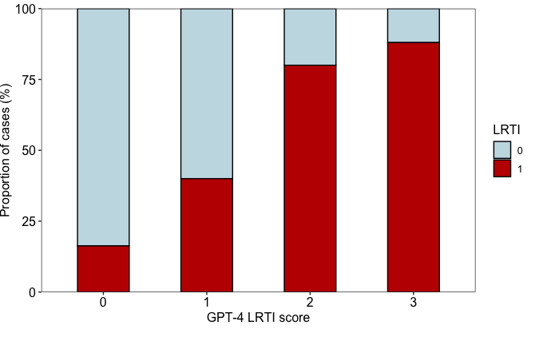

```r
ggplot(data=temp,
       aes(x=Versa.LRTI.score.factor, y=prop*100)) +
  geom_col(aes(fill=LRTI), color="black", width=0.5) +
  scale_fill_manual(
    values=c("0"="#c7dde5", "1"="#c00000")) +
  scale_y_continuous(
    limits=c(0,100), expand=c(0,0)) +
  labs(x="GPT-4 LRTI score",
       y="Proportion of cases (%)") +
  theme_bw() + my.theme
```